# stat 432 hw6

Author

Lu Gong

# HW6

### question 1

```r
library(FNN)
library(pROC)

dat <- read.csv("data/breast-cancer.csv")
RNGkind("Mersenne-Twister", "Inversion", "Rejection")
set.seed(43206)
train_id <- sort(sample.int(nrow(dat), floor(0.7 * nrow(dat))))
train <- dat[train_id, ]
test <- dat[-train_id, ]
predictors <- c("mean_radius", "mean_texture", "mean_smoothness")

train_mean <- colMeans(train[, predictors])
train_sd <- sapply(train[, predictors], sd)
x_train <- scale(train[, predictors], center = train_mean, scale = train_sd)
x_test <- scale(test[, predictors], center = train_mean, scale = train_sd)
y_train <- train$y
y_test <- test$y

fit <- glm(y ~ ., data = data.frame(y = y_train, x_train), family = binomial())
k_values <- c(5, 15, 25, 35, 45)
model_names <- c("Logistic regression", paste0("KNN (k=", k_values, ")"))
probabilities <- matrix(NA, nrow(test), 6)
probabilities[, 1] <- predict(fit, newdata = data.frame(x_test), type = "response")
for (i in 1:5) {
  probabilities[, i + 1] <- knn.reg(x_train, x_test, y_train,
                                    k = k_values[i], algorithm = "brute")$pred
}

roc_curves <- vector("list", 6)
auc_values <- numeric(6)
for (i in 1:6) {
  roc_curves[[i]] <- roc(y_test, probabilities[, i], levels = c(0, 1),
                         direction = "<", quiet = TRUE)
  auc_values[i] <- as.numeric(auc(roc_curves[[i]]))
}
auc_table <- data.frame(model = model_names, test_AUC = auc_values)
```

```r
knitr::kable(auc_table, digits = 6,
             col.names = c("Model", "Test AUC"), row.names = FALSE)
```

| Model | Test AUC |
| --- | --- |
| Logistic regression | 0.975871 |
| KNN (k=5) | 0.943818 |
| KNN (k=15) | 0.962093 |
| KNN (k=25) | 0.969732 |
| KNN (k=35) | 0.975657 |
| KNN (k=45) | 0.976371 |

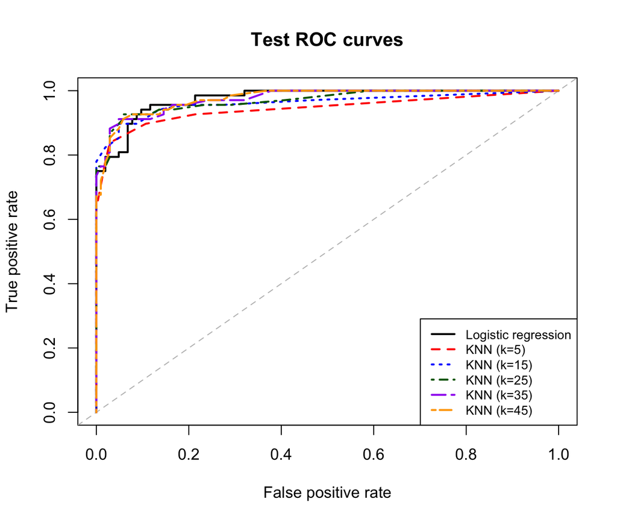

```r
colors <- c("black", "red", "blue", "darkgreen", "purple", "orange")
plot(c(0, 1), c(0, 1), type = "n",
     xlab = "False positive rate", ylab = "True positive rate",
     main = "Test ROC curves")
abline(0, 1, lty = 2, col = "gray")
for (i in 1:6) {
  lines(1 - roc_curves[[i]]$specificities, roc_curves[[i]]$sensitivities,
        col = colors[i], lty = i, lwd = 2)
}
legend("bottomright", legend = model_names,
       col = colors, lty = 1:6, lwd = 2, cex = 0.8)
```

I prefer logistic regression. Its test AUC is 0.9759, which is very close to 0.9764 for 45NN. Even though 45NN has the highest AUC, I value interpretability because this task predicts the probability of malignancy. Logistic regression makes the relationship between the predictors and the outcome easier to explain. Given the small AUC difference, I would choose logistic regression.

### question 2

```r
k_values <- c(1, 3, 5, 10, 20)
p_train <- matrix(NA, nrow(train), 5)
p_test <- matrix(NA, nrow(test), 5)
roc_train <- roc_test <- vector("list", 5)
auc_train <- auc_test <- numeric(5)
for (i in 1:5) {
  p_train[, i] <- knn.reg(train = x_train, test = x_train, y = y_train,
                          k = k_values[i], algorithm = "brute")$pred
  p_test[, i] <- knn.reg(train = x_train, test = x_test, y = y_train,
                         k = k_values[i], algorithm = "brute")$pred
  roc_train[[i]] <- roc(y_train, p_train[, i], levels = c(0, 1),
                        direction = "<", quiet = TRUE)
  roc_test[[i]] <- roc(y_test, p_test[, i], levels = c(0, 1),
                       direction = "<", quiet = TRUE)
  auc_train[i] <- as.numeric(auc(roc_train[[i]]))
  auc_test[i] <- as.numeric(auc(roc_test[[i]]))
}
q2_auc <- data.frame(k = k_values, training_AUC = auc_train, test_AUC = auc_test)
```

```r
knitr::kable(q2_auc, digits = 4,
             col.names = c("k", "Training AUC", "Test AUC"), row.names = FALSE)
```

| k | Training AUC | Test AUC |
| --- | --- | --- |
| 1 | 1.0000 | 0.8900 |
| 3 | 0.9893 | 0.9427 |
| 5 | 0.9863 | 0.9438 |
| 10 | 0.9844 | 0.9557 |
| 20 | 0.9826 | 0.9602 |

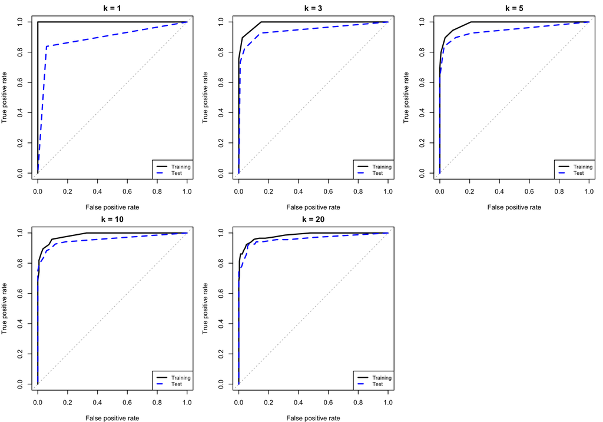

```r
old_par <- par(mfrow = c(2, 3), mar = c(4, 4, 2, 1))
for (i in 1:5) {
  plot(1 - roc_train[[i]]$specificities, roc_train[[i]]$sensitivities,
       type = "l", col = "black", lwd = 2, xlim = c(0, 1), ylim = c(0, 1),
       main = paste("k =", k_values[i]),
       xlab = "False positive rate", ylab = "True positive rate")
  lines(1 - roc_test[[i]]$specificities, roc_test[[i]]$sensitivities,
        col = "blue", lty = 2, lwd = 2)
  abline(0, 1, col = "gray", lty = 3)
  legend("bottomright", c("Training", "Test"),
         col = c("black", "blue"), lty = c(1, 2), lwd = 2, cex = 0.8)
}
plot.new()
```

```r
par(old_par)
```

When k = 1, the prediction depends on one neighbor, so the predicted probability is either 0 or 1. For a training observation, its nearest neighbor is itself. This gives a training AUC of 1, but it does not guarantee correct predictions for new observations. In our results, the test AUC is 0.8900.

As k increases, more neighbors contribute to the prediction. For example, at k = 5, changing one neighbor’s label changes the predicted probability by 0.2 instead of 1. This can make predictions more stable. In our results, increasing k from 1 to 20 raises the test AUC from 0.8900 to 0.9602, while the training AUC decreases from 1 to 0.9826. The training-test AUC gap therefore shrinks from 0.1100 to 0.0224.

However, a larger k does not always improve test performance. If k equals the number of training observations, every prediction uses the same neighbors and gives the same probability. The model can no longer distinguish between cases, and its AUC is 0.5.

### question 3

In [yanxif2’s Homework 5 report](https://github.com/yanxif2/stat432-fall2026/blob/main/homework/week-05/homework-05.html), Question 2(a), the MSE values in the results table do not match those reported in the paragraph immediately below it. For example, the table reports a KNN MSE of 0.5616 for the independent setting, while the paragraph reports 0.5565. For the correlated setting, the table reports 0.1876, while the paragraph reports 0.1609.

The paragraph states:

> Independent 0.5565 / 0.2602; Correlated 0.1609 / 0.2259

I think this inconsistency may have been an oversight.

Using the displayed results table as the reference, the corrected summary is:

| Setting | KNN MSE | Lasso MSE |
| --- | --- | --- |
| Independent | 0.5616 | 0.2394 |
| Correlated | 0.1876 | 0.2731 |

Lasso has the lower test MSE in the independent setting, while KNN has the lower test MSE in the correlated setting. The revision should replace the four MSE values in the paragraph with those in the table. The table and paragraph should be generated from the same saved results so that they remain consistent. This correction reconciles the paragraph with the displayed table; it does not claim that the original simulation has been rerun.

Posted review: [GitHub Issue](https://github.com/yanxif2/stat432-fall2026/issues/2).